# Diffrac

Miravet-Verde, Samuel

March 15, 2016

### Introduction

Deep sequencing technology is able to sequence each base at least 100 times. This gives a very good resolution to do omic studies. The output of the machine are, basically, files with a column with each position of the bacterial genome and a second and third values with the expression at that base for + and - strand.

The goal of this project is to be able to discriminate different signals (starting signals, termination signals, decay) from deep sequencing transcriptomics files.

### Test

This is just a space to test how we are going to work:

The workspace where we are working:

```r
setwd("/home/smiravet/crg/diffrac")
```

Functions:

```r
plot_coverage <- function(mini, maxi){

  # Plot the figure
  plot(dsspilesmpn[which(mini<dsspilesmpn$position & dsspilesmpn$position<maxi),]$plus~dsspilesmpn[which(mini<dsspilesmpn$position & dsspilesmpn$position<maxi),]$position,
       ylim = range(min(dsspilesmpn[which(mini<dsspilesmpn$position & dsspilesmpn$position<maxi),]$minus*-1), max(dsspilesmpn[which(mini<dsspilesmpn$position & dsspilesmpn$position<maxi),]$plus)),
       main = paste("Coverage plot",mini,'-', maxi),
       xlab = "MPN genome",
       ylab='coverage',
       col = 'lightskyblue',
       type='h')
  lines(dsspilesmpn[which(mini<dsspilesmpn$position & dsspilesmpn$position<maxi),]$minus*-1~dsspilesmpn[which(mini<dsspilesmpn$position & dsspilesmpn$position<maxi),]$position, type='h', col = 'rosybrown1')
}
```

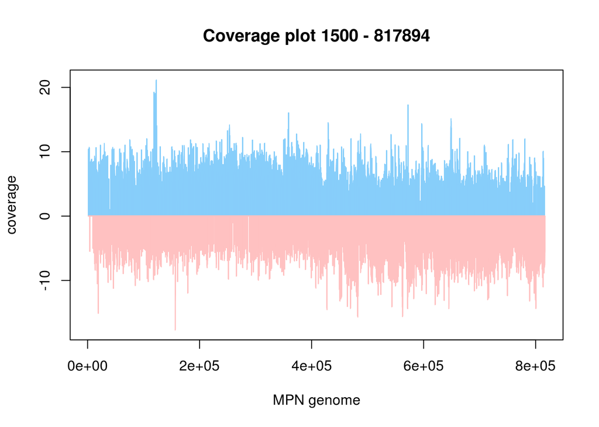

```r
dsspilesmpn <- read.delim("~/crg/diffrac/datasets/dsspilesmpn.txt")
colnames(dsspilesmpn) <- c('position', 'minus', 'plus')

dsspilesmpn$plus <- log2(dsspilesmpn$plus+1)
dsspilesmpn$minus <- log2(dsspilesmpn$minus+1)

minlim <- 0
maxlim <- 816394

minlim <- minlim+1500
maxlim <- maxlim+1500
plot_coverage(minlim, maxlim)
```

# Conceptual definition of the problem:

Conceptually we can have the followin types of behaviour in the expression profile:

- Gradual positive: expression increasing gradually from one base to the next. No genomic features expected to have this profile.
- Strictly positive: a peak in the expression profile after which the expression is maintained after time. Expected for promoters.
- Transient positive peak: it shows a positive peak followed by a reduction of the levels (negative peak) but without arriving to zero. Expected for promoters.
- Static: expression maintained. Expected for genes or intergenic (0 expression) regions.
- Transient negative peak: it shows a negative peak but fully or partially recovered at the next bases. No genomic features expected to have this profile.
- Strictly negative: a drastic drop in the expression, the next step should be 0. This signal should come from an intrinsic terminator.
- Gradual negative: a gradual decay in expression.

```r
plot4d <- function(x, lg = 1, t = 'l'){
  # Given a vector x, plot the 1st, 2nd and 3rd derivative
  # If x is a vector of length n and differences = 1, then the computed result is equal to the successive differences x[(1+lag):n] - x[1:(n-lag)].
  # t allows to define the type of plot we want (hist, points, line), line by default

  dx <- diff(x, lg)
  ddx <- diff(dx, lg)
  dddx <- diff(ddx, lg)

  par(mfrow=c(2,2))
  plot(x, t=t)
  plot(dx, t=t)
  plot(ddx, t=t)
  plot(dddx, t=t)
}
```

## Gradual positive

This depends in the gradual change. If it is one by one the profile for the first derivative will be fixed at the change value and to 0 in the ddx and dddx

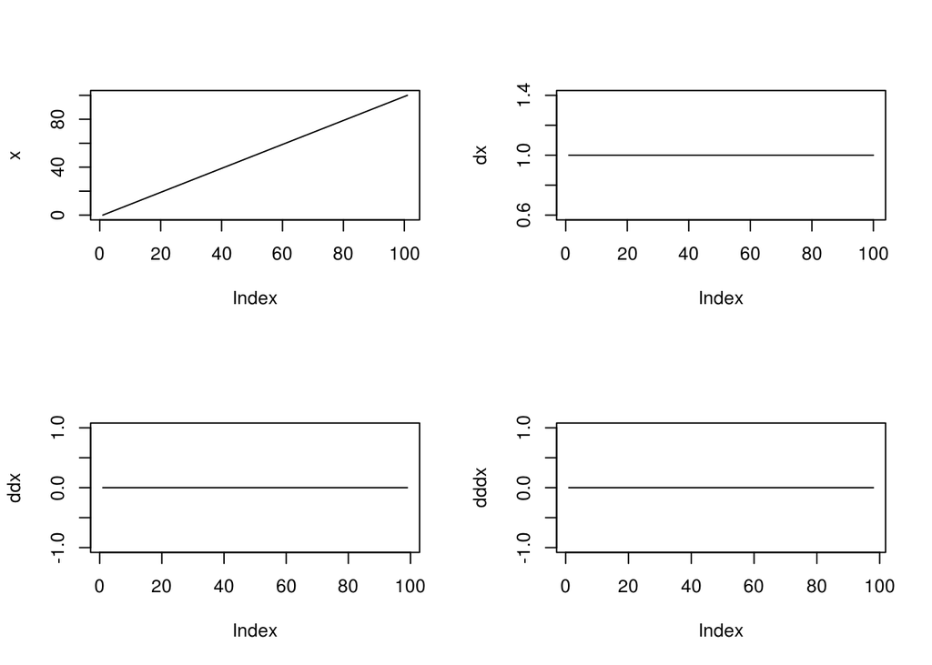

```r
gradualpositive <- 0:100
plot4d(gradualpositive)
```

If we have a irregular increment:

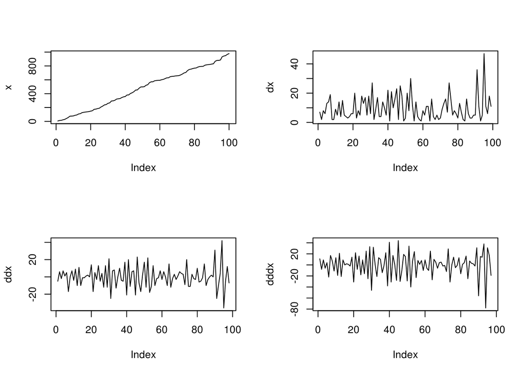

```r
gradualpositive <- sort(sample(0:1000, 100))
plot4d(gradualpositive)
```

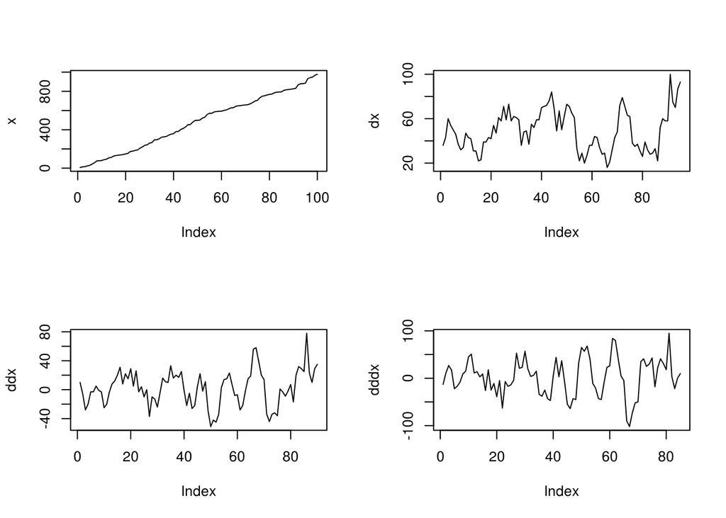

```r
plot4d(gradualpositive,5)
```

We see that we have an irregular profile but the key is that the first derivative has always positive values:

```r
diff(gradualpositive)
```

```
##  [1]  7  2  8  6 13 14 19  2  2  9  5 14  4 15  5  4  3  4  6  6 20  3  8
## [24]  5 18 13 17  5 18  6 27  2  9 17  4  4 14 10  5 22  1 21 10 16 23  2
## [47] 25 18  1  3 20  8 30 12  1 14  4  2  1  8  5 11 11  1 16  4  2  5  2
## [70]  3  9 13 16  7 27 16  5  8  6  3 13  7  2  1 16  6  3  3  5  5 36 11
## [93]  1  5 47 11  6 18 11
```

It can be maintained after time and the peak will drop from positive to 0 in the dx

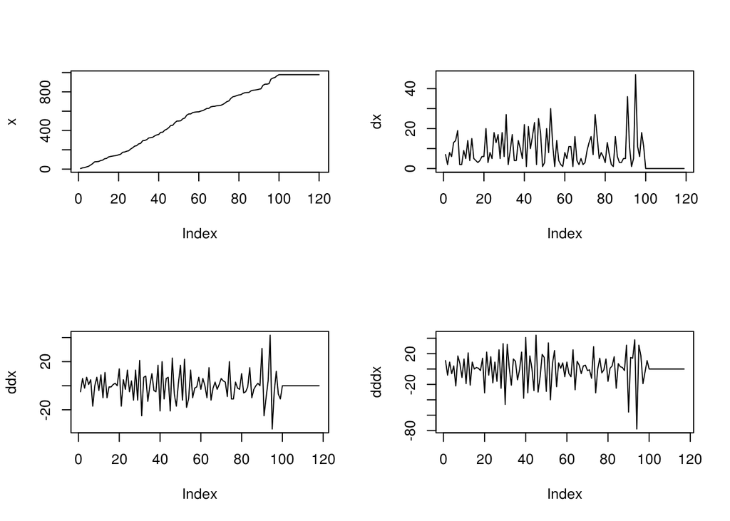

```r
gradualpositive <- c(gradualpositive, rep(max(gradualpositive), 20))  # We add the maximum value 20 times
plot4d(gradualpositive)
```

## Strictly positive

In this case we have to see a peak in expression maintained after time:

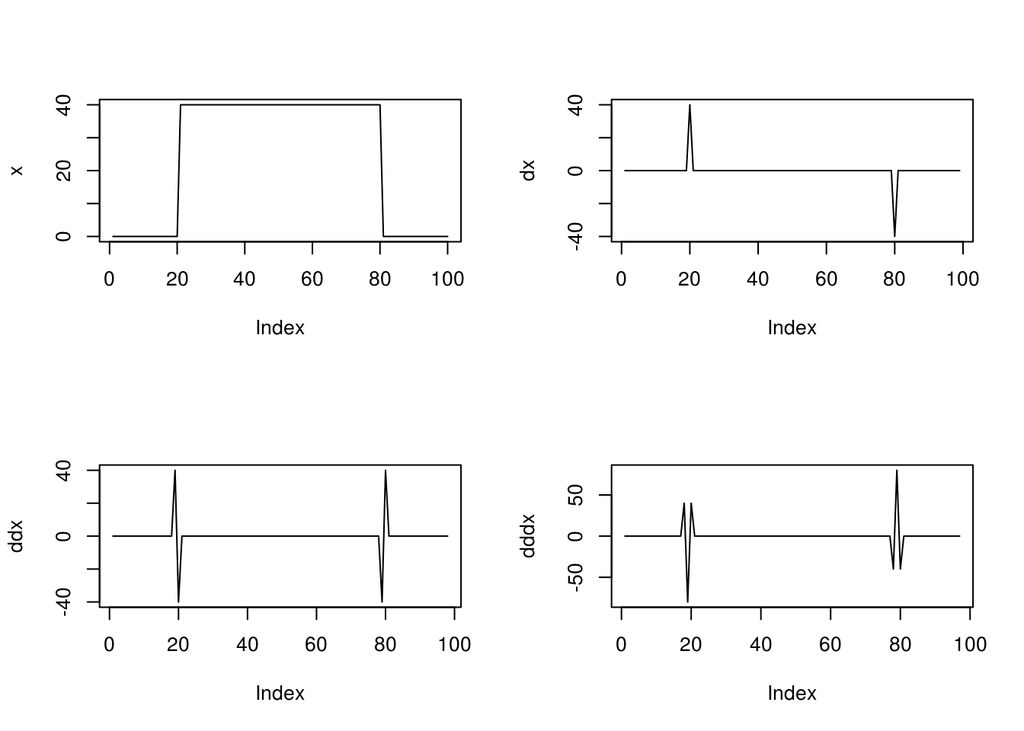

```r
stictlypositive <- c(rep(0,20), rep(40,60), rep(0,20))
plot4d(stictlypositive)
```

## Transient positive

In this case we have to see a peak in expression followed by a small decay:

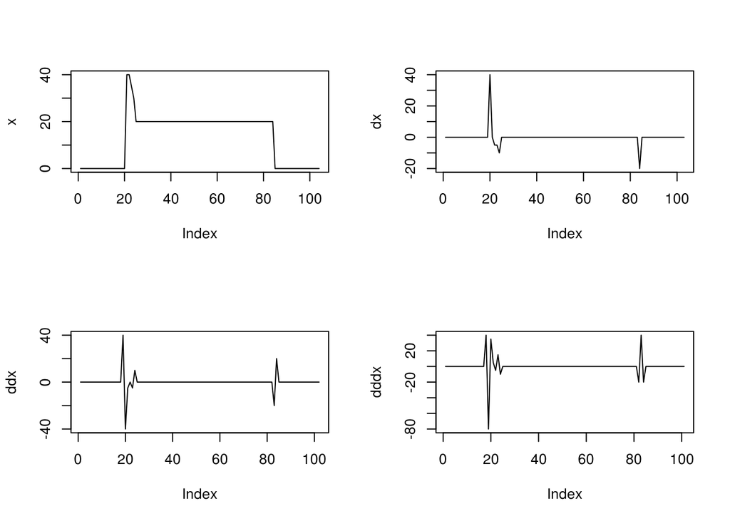

```r
transientpositive <- c(rep(0,20), 40, 40, 35, 30, rep(20,60), rep(0,20))
plot4d(transientpositive)
```

## Static

In this case we see no change between values (all dx 0)

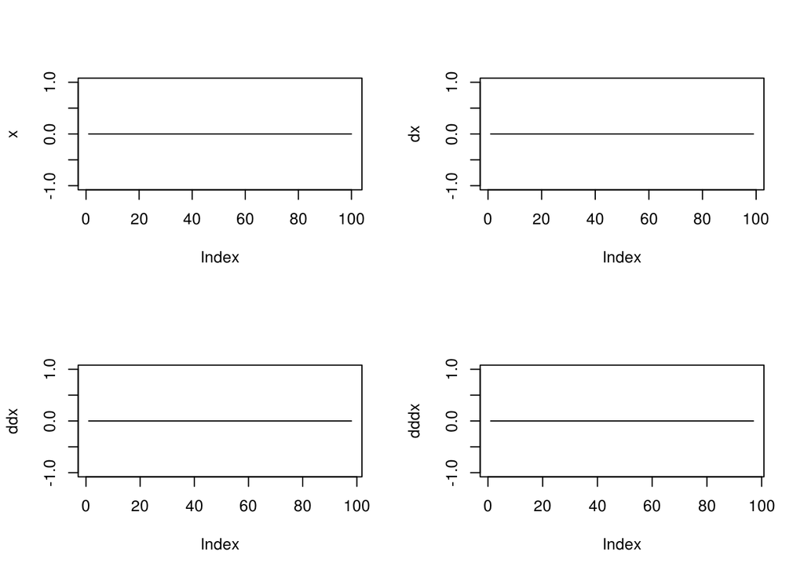

```r
static <- c(rep(0,100))
plot4d(static)
```

The same independently the value (only x changes)

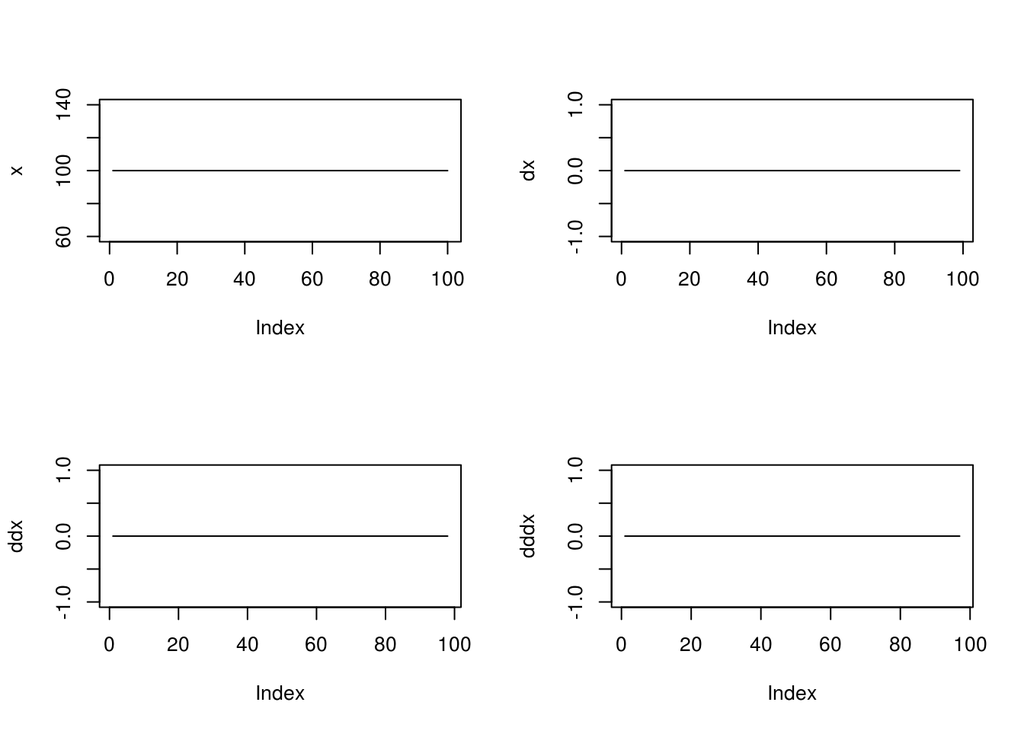

```r
static <- c(rep(100,100))
plot4d(static)
```

## Transient negative

In this case we have to see a drop in expression followed by a small recovery:

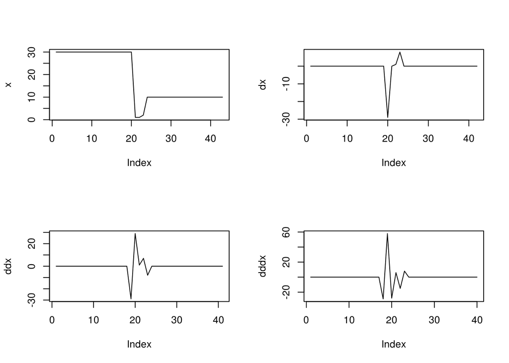

```r
transientnegative <- c(rep(30,20), 1, 1, 2, rep(10,20))
plot4d(transientnegative)
```

## Strictly negative

In this case we have to see a drop in expression maintained after time:

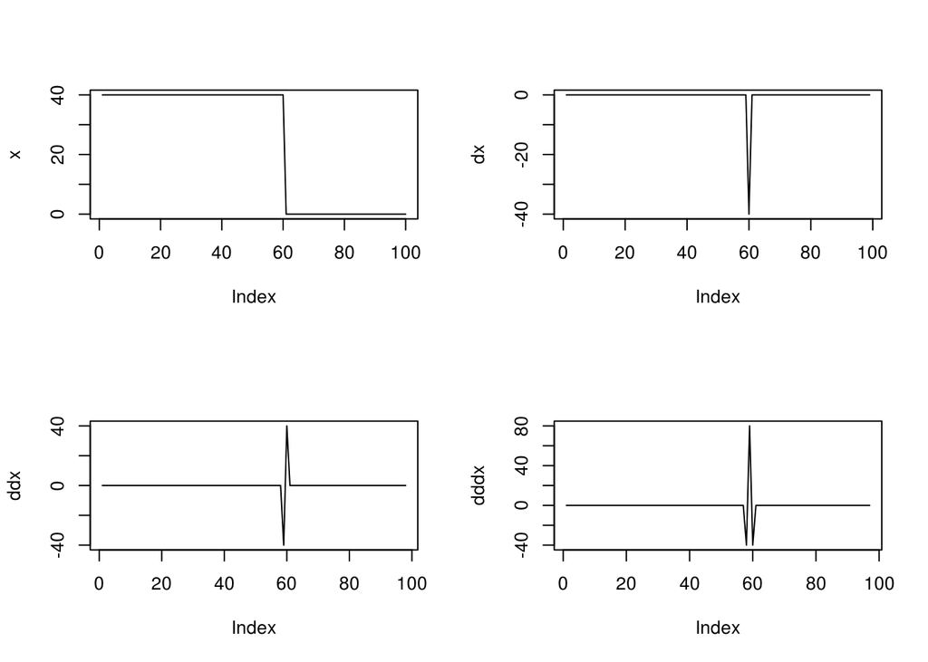

```r
strictlynegative <- c(rep(40,60), rep(0,40))
plot4d(strictlynegative)
```

## Gradual negative

This depends in the gradual change. If it is one by one the profile for the first derivative will be fixed at the change value and to 0 in the ddx and dddx

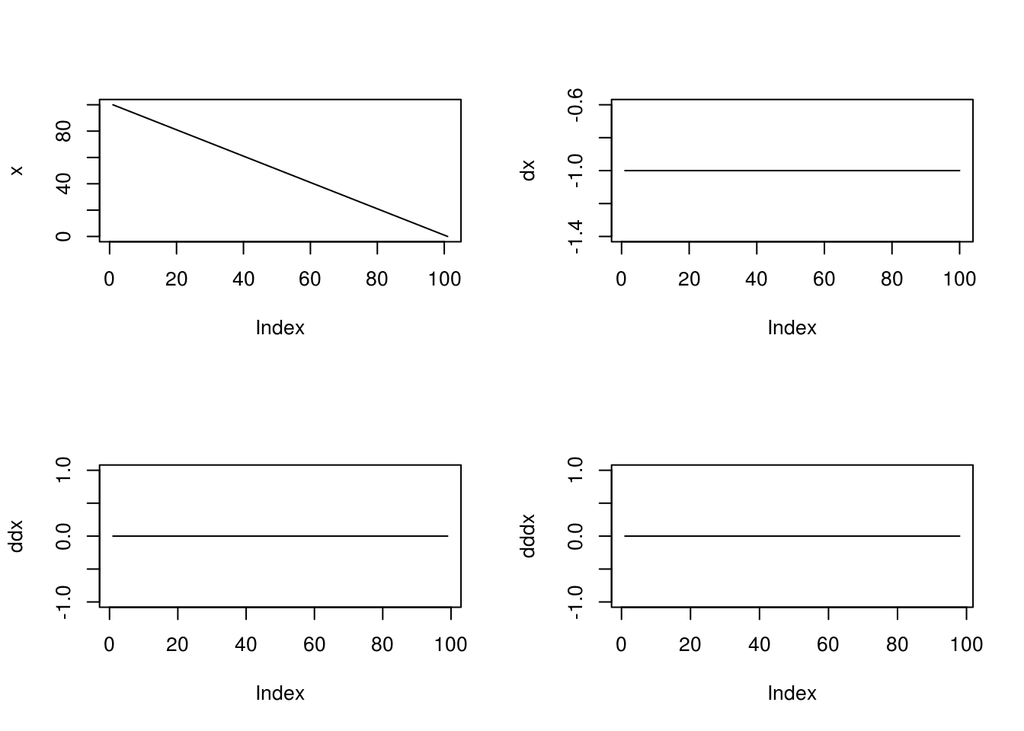

```r
gradualnegative <- 100:0
plot4d(gradualnegative)
```

If we have a irregular increment:

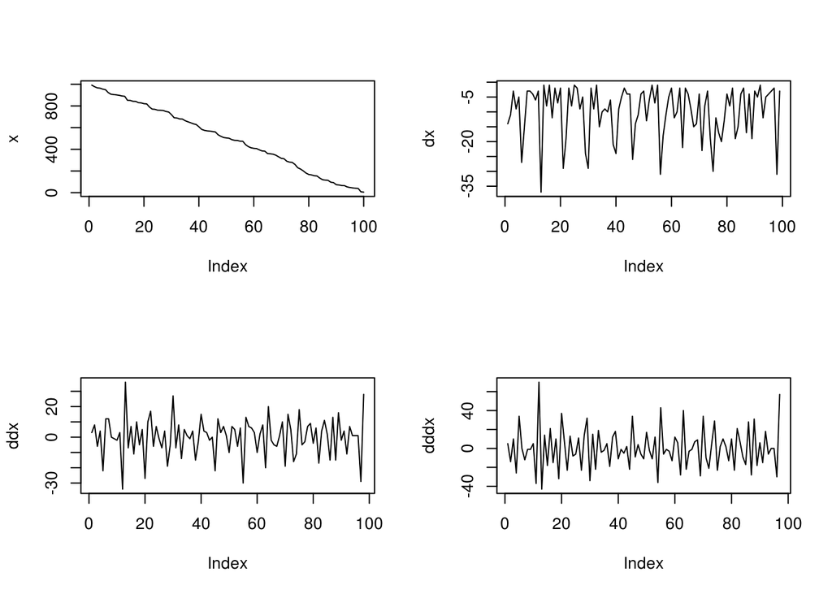

```r
gradualnegative <- sort(sample(1000:1, 100), decreasing = T)
plot4d(gradualnegative)
```

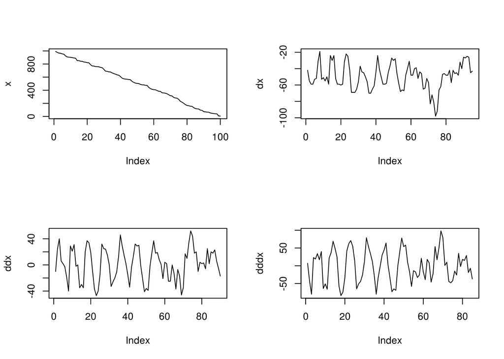

```r
plot4d(gradualnegative,5)
```

We see that we have an irregular profile but the key is that the first derivative has always negative values:

```r
diff(gradualnegative)
```

```
##  [1] -14 -11  -3  -9  -5 -27 -15  -3  -3  -4  -6  -3 -37  -1  -8  -1 -12
## [18]  -2  -7  -2 -29 -19  -2  -8  -1  -2  -9  -5 -24 -29  -2  -9  -1 -15
## [35] -10  -9 -10  -6 -21 -24  -9  -5  -2  -4  -4 -26 -14 -11  -4  -3 -13
## [52]  -6  -1  -7  -1 -31 -18 -11  -5  -2 -12 -10  -2 -22  -2  -4  -9 -15
## [69] -14  -4 -23  -8  -3 -19 -30 -12 -17 -20 -13  -4  -8  -2 -19 -15  -4
## [86]  -2 -17  -4 -19  -3  -5  -1 -12  -5  -4  -3  -2 -31  -3
```

It can be maintained after time and the peak will raise from negative to 0 in the dx

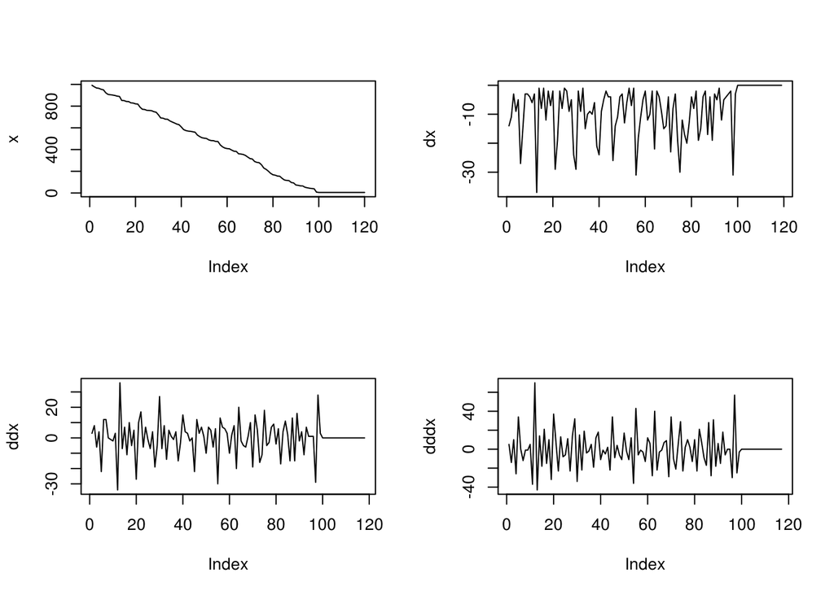

```r
gradualnegative <- c(gradualnegative, rep(min(gradualnegative), 20))  # We add the maximum value 20 times
plot4d(gradualnegative)
```

We usually see this fitting and logarithmic decay:

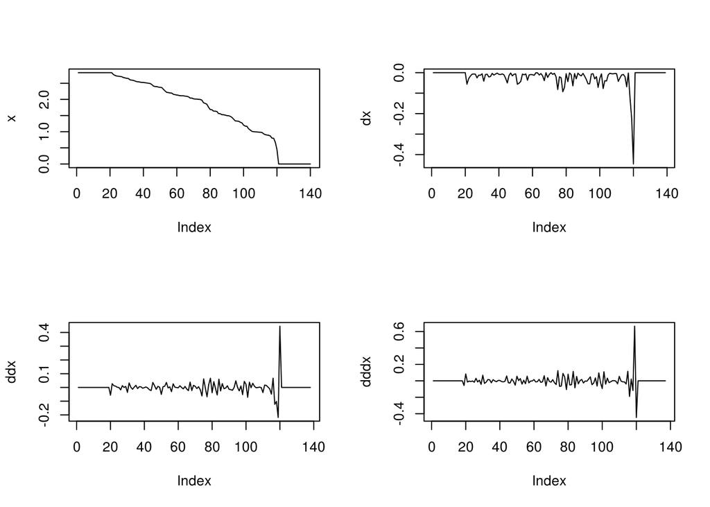

```r
C<-3
k<-2
x<-seq(100,1200,1)/1000
y<-C*(1-exp(-k*x))+rnorm(length(x),sd=0.1)
y <- sort(sample(unique(y),100), decreasing=T)

gradualnegative <- c(rep(max(y), 20), y, rep(0,20))  # We add the maximum value 20 times
plot4d(gradualnegative)
```